# MNS Practical 7

$\textbf{MNS_Practical 7}$\ Leonard Hollander

```python
import numpy as np
import matplotlib.pyplot as plt
import warnings

#warnings.filterwarnings('ignore')
```

$\textbf{Exercise 1: Hodgkin-Huxley model of action potential generation}$

```python
def alpha_n (V):

    return .01 * (V + 55) / (1 - np.exp(-.1 * (V + 55)))

def beta_n (V):

    return .125 * np.exp(-.0125 * (V + 65))

def alpha_m (V):

    return (.1 * (V + 40)) / (1 - np.exp(-.1 * (V + 40)))

def beta_m (V):

    return 4 * np.exp(-.0556 * (V + 65))

def alpha_h (V):

    return .07 * np.exp(-.05 * (V + 65))

def beta_h (V):

    return 1 / (1 + np.exp(-.1 * (V + 35)))
```

```python
#Euler function to solve systems of couple ODEs

def euler(f_func, x_0, t_max, dt):

    x = x_0
    nsteps = int(t_max / dt)
    xs = np.zeros((nsteps, x_0.shape[0]))
    xs[0:,] = x_0
    i = 1
    t = 0

    while i < nsteps:

        x = x + f_func(x,t)*dt
        xs[i:,] = x
        t += dt
        i += 1

    return xs
```

```python
#Defining initial conditions:

m_0 = .0529
h_0 = .5961
n_0 = .3177
```

```python
#Potassium constants:

E_k = -77 #mV
gk_max = 36 #nS

#Sodium constants:

E_Na = 50
gNa_max = 120

#Leak current:

g_leak = .3
E_leak = -54.387
```

$\textbf{Part[a]: Solvig the system of ODEs}$

```python
#Defining initial conditions:

def init_cond(n_0 = n_0, h_0 = h_0, m_0 = m_0, V_0 = -65):

    return np.array([n_0, h_0, m_0, V_0])
```

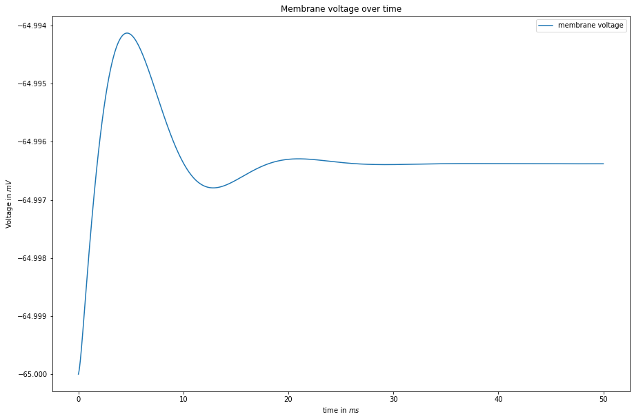

```python
#Defining some Hodgking-Huxley constants:

def func (x,t, I_e):

    n = x[0]
    h = x[1]
    m = x[2]
    V = x[3]

    #Define temporal dynamics of channel gates:

    dndt = alpha_n(V) * (1 - n) - beta_n(V) * n
    dhdt = alpha_h(V) * (1 - h) - beta_h(V) * h
    dmdt = alpha_m(V) * (1 - m) - beta_m(V) * m

    #Current equations:

    I_Na = gNa_max * np.power(m,3) * h * (V - E_Na)
    I_k = gk_max * np.power(n,4) * (V - E_k)
    I_leak = g_leak * (V - E_leak)

    #Get the voltage:

    dVdt = - I_Na - I_k - I_leak + I_e

    return np.array([dndt, dhdt, dmdt, dVdt])

#Current with zero applied current I_e:

zero_func = lambda x,t: func(x,t, I_e = 0)
result = euler(zero_func, init_cond(), 50, .01)

#Plot the results:

plt.figure(figsize = (15, 10))

plt.plot(np.arange(0,50,.01 ), result[:,3], \
         label = 'membrane voltage')
plt.title('Membrane voltage over time')
plt.xlabel('time in $ms$')
plt.ylabel('Voltage in $mV$')
plt.legend()
plt.ticklabel_format(useOffset=False)
```

$\textbf{Comment:}$The curve thus exactly matches the one we were told to expect. Good, that's reassuring. The dampened osciallations that we see are results, I guess, of (minute) sodium channel activity. At the resting potential, none of the sodium channels are active, but not all of them are inactivated (compare plots from last week). That's why we see a little sodium peak to the left. The membrane then, after a couple more oscialltions, stabilizes (this is more or less a poke in the dark).

$\textbf{Part[b]: Applying a constant external current}$

```python
#Defining new current response:

def plot_b(tmax = 50):

    #Defining time range:

    time = np.arange(0,50, .01)

    twenty_func = lambda x,t: func(x,t, I_e = 20)
    result2 = euler(twenty_func, init_cond(), tmax, .01)

    n2 = result2[:,0]
    h2 = result2[:,1]
    m2 = result2[:,2]
    V2 = result2[:,3]

    I_Na = gNa_max * np.power(m2,3) * h2 * (V2 - E_Na)
    I_k = gk_max * np.power(n2,4) * (V2 - E_k)

    fig, axs = plt.subplots(2,2, sharex = False, sharey = False, \
                           figsize = (25, 25))

    #Plot currents I_k and -I_Na:

    axs[0,0].plot(time, I_k / 1000, label = 'Potassium')
    axs[0,0].plot(time, -I_Na / 1000, label = 'Sodium')
    axs[0,0].set_xlabel('time in $ms$')
    axs[0,0].set_ylabel('Current in $nA$')
    axs[0,0].set_title('Potassium and negative sodium current over time')
    axs[0,0].legend()

    axs[0,1].plot(time, n2, label = '$n$')
    axs[0,1].plot(time, h2, label = '$h$')
    axs[0,1].plot(time, m2, label = '$m$')
    axs[0,1].set_xlabel('time in $ms$')
    axs[0,1].set_title('Gating variable $n$, $h$ & $m$ over time')
    axs[0,1].set_ylabel('Probability of open channel')
    axs[0,1].legend()

    axs[1,0].plot(V2, n2, label = '$n$')
    axs[1,0].set_xlabel('Voltage in $mV$')
    axs[1,0].set_ylabel('Gating variable $n$ (probability of opening)')
    axs[1,0].set_title('Gating variable $n$ over voltage')
    axs[1,0].legend()

    axs[1,1].plot(V2, I_k / 1000, label = '$I_k$')
    axs[1,1].set_xlabel('Voltage in $mV$')
    axs[1,1].set_ylabel('Current in $nA$')
    axs[1,1].set_title('Potassium current over voltage')
    axs[1,1].legend()
```

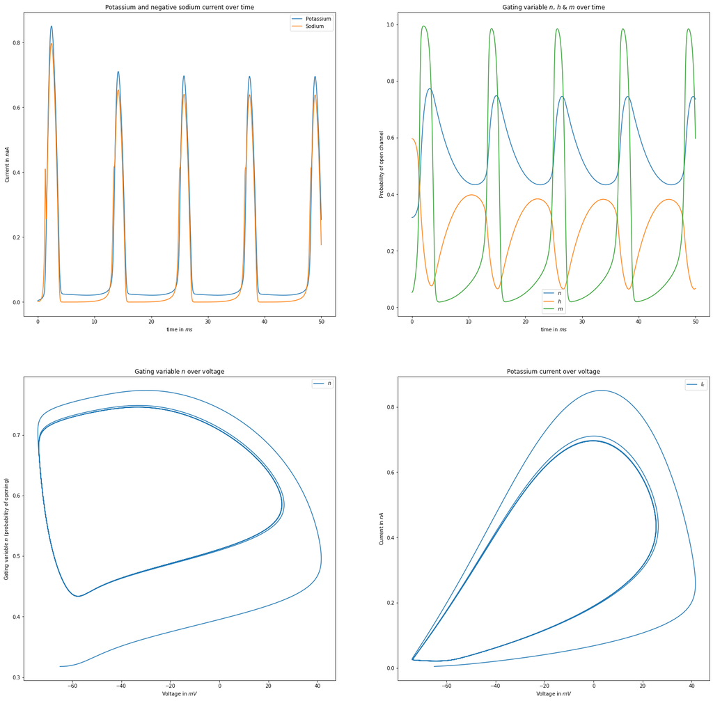

```python
#Plotting results:
plot_b()
```

$\textbf{Part[c]: Firing rates}$

```python
from scipy.signal import find_peaks
```

[figure not shown]

```python
def plot_firing_rate (tmax = 100):

    time = np.arange(0,tmax,.01)

    current_range = np.arange(0,20)

    firing_rates = np.zeros(current_range.shape[0])

    result_func = lambda I_e: euler(lambda x,t: func(x,t, I_e), \
                                    init_cond(), tmax, 0.01)

    fig, axs = plt.subplots(2,2, sharex = True, sharey = False, \
                               figsize = (15,15))

    plt.suptitle('Firing rate in response to constant injected current $I_e$')
    #Counter variables to allocate plots:

    i = 0
    j = 0

    for cI, current in np.ndenumerate(current_range):

        n3 = result_func(current)[:,0]
        h3 = result_func(current)[:,1]
        m3 = result_func(current)[:,2]
        V3 = result_func(current)[:,3]

        I_Na = gNa_max * np.power(m3,3) * h3 * (V3 - E_Na)
        I_k = gk_max * np.power(n3,4) * (V3 - E_k)
        I_leak = I_leak = g_leak * (V3 - E_leak)

        total_current = -I_Na - I_k - I_leak + current

        if (cI[0] % 5 == 0):

            axs[i,j].plot(time,total_current)
            axs[i,j].set_title('$I_e$ = {} $pA$'.format(current))
            axs[i,j].set_xlabel('time in $ms$')
            axs[i,j].set_ylabel('Total current in $pA$')

            if (cI[0] % 10 != 0):

                i += 1
                j -= 1

            elif (cI[0] % 10 == 0):

                j += 1


        #Get the firing rates:

        firing_rates[cI] = \
        find_peaks(total_current, height = 100)[0].shape[0] / tmax


    return firing_rates


firing_rates = plot_firing_rate()
```

$\textbf{Answer:}$ From these plots we could be tempted surmise that a reasonable threshold for spikes is about 200 nA. This is in fact not true, the reason being that at driving currents of higher magnitudes the spikes do not reach up all the way to 200 (in some sense this is already foreshadowed in the bottom-row plots, which show a significant decrease in spike-amplitude between 10 and 15 nA. I ran the same simulation with different plots and settled on a 100 nA as a good threshold.\ We begin to see actual firing patterns at around 6nA (the asked-for $rheobase$). For smaller currents, we see some smaller peaks. However, in real world scenarios these would not suffice to spark an action potential as they are too small to pass the axon hillock. Moreover, especially if we look at the top-right figure, we see that we can sometimes see single, isolated spikes. These are direct results of the injected current, but the current in these cases isn't strong enough to generate a whole pattern of neural firings. Taking these facts into account we should only count spikes that cross this threshold and, moreover, only count them when there are sufficiently many of them to actually compose a fully fledged firing pattern. The firing rates we obtain (by counting only spikes that cross the threshold) at different driving currents are shown in the figure below.

$\textbf{Part[d]: Changing the current}$

[figure not shown]

```python
#Plotting firing rate over driving current:

firing_rates = np.where(firing_rates > .02, firing_rates, 0)

plt.figure(figsize = (25,15))
plt.plot(np.arange(0,20), firing_rates)
plt.title('Firing rate over injected current')
plt.xlabel('Injected current in $pA$')
plt.ylabel(r'Firing rate in $\frac{spikes}{ms}$')
```

$\textbf{Answer:}$ We can see that the $rheobase$ is somewhere around $\approx$ 6nA (might be quite far away, due to resolution issues). The marked difference when comparing this plot with the firing rates of the leaky integrate and fire neuron is that the firing rate here doesn't increase linearly (compare analytical solution from sheet 5). Instead, we see a number of plateaus where the firing rate remains constant (which, in contrast to the empirical plot in the earlier sheet, are not mere artefacts of our plotting resolution). These might grow longer as we increase the current and, plausibly, saturate to a point where the neuron – because of its physiological limitations – simply cannot fire any faster.

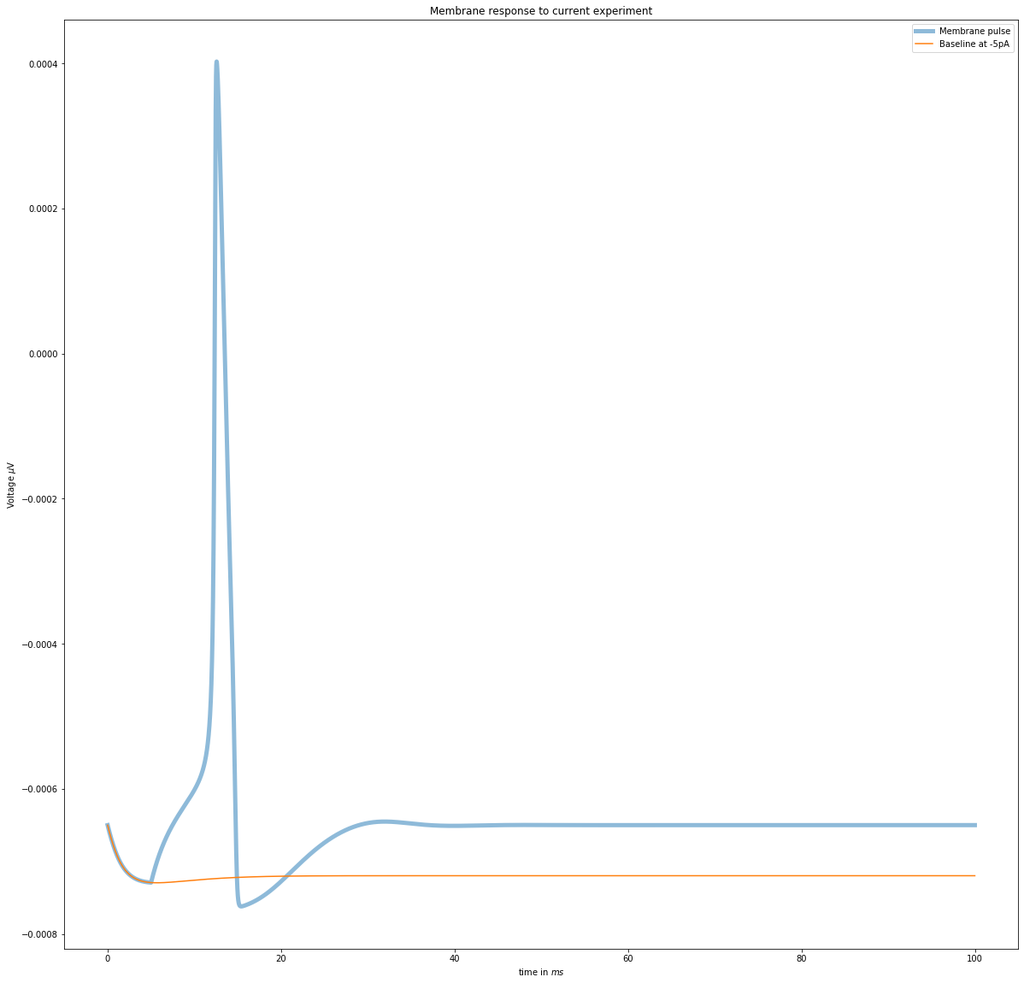

```python
#Defining current_clamp function:

def clamp_func (x,t, V_c = -5):

        return func(x,t, I_e = V_c) if t <= 5 else zero_func(x,t)

#Defing baseline function:

def baseline_func (x,t):

        return func(x,t,I_e = -5)


#Plotting the membrane response:

plt.figure(figsize = (20,20))

plt.plot(np.arange(0,100, .01), clamp_result[:,3] * 10e-6,  \
         linewidth = 5, alpha = .5, label = 'Membrane pulse')
plt.plot(np.arange(0,100,.01), compare_result[:,3] * 10e-6, label = 'Baseline at -5pA')
plt.title('Membrane response to current experiment')
plt.xlabel('time in $ms$')
plt.ylabel('Voltage $\mu$V')
plt.legend()
```

How does this picture relate to the biological reality modelled by the Hodgkin-Huxley model. I would think that what is depicted here is a sort of 'release response' to the lifting of the negative step current or – in more biologically plausible terms – a response to a release of inhibition.

```python
#Plotting the results as in (b):

def plot_d(tmax = 50):

    #Defining time range:

    time = np.arange(0,50, .01)

    clamp_result = euler(clamp_func, init_cond(), tmax, .01)
    baseline_result = euler(baseline_func, init_cond(), tmax, .01)

    n3 = clamp_result[:,0]
    h3 = clamp_result[:,1]
    m3 = clamp_result[:,2]
    V3 = clamp_result[:,3]

    """

    #Baseline parameters for comparison:

    n_base = baseline_result[:,0]
    h_base = baseline_result[:,1]
    m_base = baseline_result[:,2]
    V_base = baseline_result[:,3]

    """


    I_Na = gNa_max * np.power(m3,3) * h3 * (V3 - E_Na)
    I_k = gk_max * np.power(n3,4) * (V3 - E_k)

    """
    #Baseline currents:

    I_Na_base = gNa_max * np.power(m_base,3) * h_base * (V_base - E_Na)
    I_k_base = gk_max * np.power(n_base,4) * (V_base - E_k)

    """

    fig, axs = plt.subplots(2,2, sharex = False, sharey = False, \
                           figsize = (25, 25))


    #Plot currents I_k and -I_Na:

    axs[0,0].plot(time, I_k / 1000, label = 'Potassium')
    axs[0,0].plot(time, -I_Na / 1000, label = 'Sodium')

    """
    axs[0,0].plot(time, I_k_base / 1000, c = 'C0', linewidth = 5,\
                  alpha = .5,  label = 'Baseline Potassium')
    axs[0,0].plot(time, -I_Na_base / 1000, c = 'C1', linewidth = 5,\
                  alpha = .5,  label = 'Baseline Sodium')
    """

    axs[0,0].set_xlabel('time in $ms$')
    axs[0,0].set_ylabel('Current in $\mu$A')
    axs[0,0].set_title('Potassium and negative sodium current over time')
    axs[0,0].legend()

    axs[0,1].plot(time, n3, label = '$n$')
    axs[0,1].plot(time, h3, label = '$h$')
    axs[0,1].plot(time, m3, label = '$m$')

    """
    axs[0,1].plot(time, n_base, c = 'C0', linewidth = 5,\
                  alpha = .5, label = '$n_{baseline}$')
    axs[0,1].plot(time, h_base, c = 'C1', linewidth = 5,\
                  alpha = .5,label = '$h_{baseline}$')
    axs[0,1].plot(time, m_base, c = 'C2', linewidth = 5,\
                  alpha = .5,label = '$m_{baseline}$')
    """

    axs[0,1].set_xlabel('time in $ms$')
    axs[0,1].set_title('Gating variable $n$, $h$ & $m$ over time')
    axs[0,1].legend()

    axs[1,0].plot(V3, n3, label = '$n$')

    """
    axs[1,0].plot(V_base, n_base, c = 'C0', linewidth = 5,\
                  alpha = .5,label = '$n_{baseline}$')

    """

    axs[1,0].set_xlabel('Voltage in $mV$')
    axs[1,0].set_ylabel('Gating variable $n$')
    axs[1,0].set_title('Gating variable $n$ over voltage')
    axs[1,0].legend()

    axs[1,1].plot(V3, I_k / 1000, label = '$I_k$')

    """
    axs[1,1].plot(V_base, I_k_base / 1000, c = 'C0', linewidth = 5,\
                  alpha = .5, label = 'Baseline $I_k$')

    """

    axs[1,1].set_xlabel('Voltage in $mV$')
    axs[1,1].set_ylabel('Current in $\mu$A')
    axs[1,1].set_title('Potassium current over voltage')
    axs[1,1].legend()
```

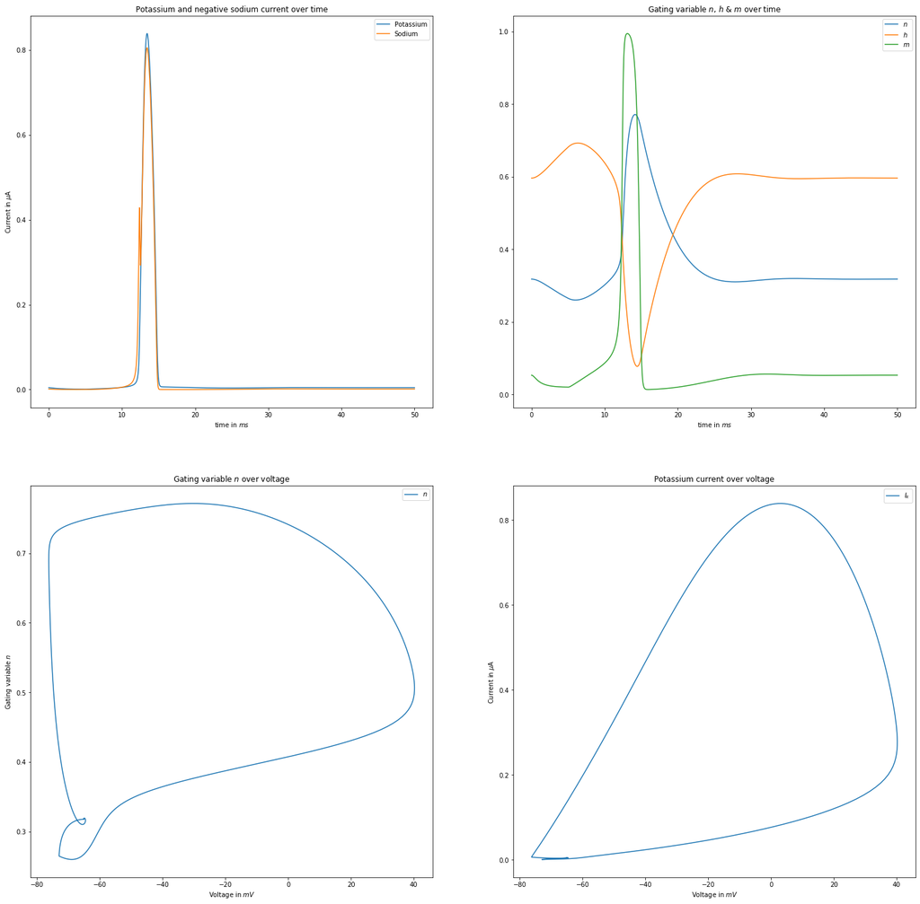

```python
plot_d()
```